# Análisis de Ingresos por Género - ESI

# Resumen

Hola, mi nombre es Simón y este es un proyecto propio realizado a partir de las bases de datos de la Encuesta Suplementaria de Ingresos (ESI). Si bien el objetivo principal es analizar de manera descriptiva, inferencial y una interpretación sociológica, el foco está también en el uso de R como medio para obtener toda la información.

En este proyecto se llevó a cabo una manipulación de múltiples dataframe, filtrando valores perdidos, recodificando valores en distintas tipos de variables (cuantitativas, nominales e ordinales). Asimismo, se manipuló 6 bases de datos simultáneamente a través de bucles for, lo cual permitió optimizar el código con buenas prácticas de programación, esto incluye el asignar nuevos objetos que faciliten la legibilidad del código, y operaciones matemáticas para mejorar la presentación principalmente de los ingresos principales y su interación con otras variables.

El presente enfoque describe los ingresos de la Ocupación principal por sexo y las brechas de género dentro del mercado laboral chileno, tomando como punto de partida las principales estimaciones publicadas por esta encuesta. Por otra parte, señalar el uso de antecedentes previos para delimitar el estudios, tales como los informes de la Organización Internacional del Trabajo (OIT), como también datos del Grupo Banco Mundial, entre otros.

Cabe destacar que el presente proyecto está aún en proceso de su construcción, por lo que su estructura difiere del formato estándar de introducción, desarrollo, conclusión. Me gustaría mencionar que existen más variables en el análisis final, tales como los análisis entre Sectores Económicos (Primaria, Secundaria y Terciaria) según sexo e ingresos principales, como también el análisis según Grupo de Ocupación (Directivos, Profesionales, Técnicos, etc. ).

-Preparación de las bases de datos para su manipulación

-Análisis descriptivo y bivariado de la Encuesta más actual (2022)

-Evolución de las variables relevantes en el tiempo

Espero que les guste y mencionarles que cualquier retroalimentación es siempre bienvenida.

### Inicio

```r
# Cargar paquetes necesarios

library(prettydoc)
library(tidyverse)
library(haven)
library(wesanderson)
library(grid)
library(psych)
library(forcats)
library(scales)
library(knitr)
library(kableExtra)
library(broom)
```

#Carga de las bases de datos

### ESI 2017-2022

Necesitamos darle un formato adecuado a cada dataframe. Realizamos un bucle con lapply, leyendo cada archivo .sav, que empiece con esi, luego el año sin espacios y el .sav Asimismo, seleccionamos las columnas a utilizar en el análisis.

#### Tratamiento de las variables

```r
#Cargamos los datasets
años <- 2017:2022
data_list <- lapply(años, function(año) read_sav(paste0("esi", año, ".sav")))

# Se seleccionan las columnas relevantes: sexo, ocupación, ingresos, etc.
data_list <- lapply(data_list, function(df) {
  df %>%
    select(any_of(c("sexo", "ocup_ref", "ing_t_p", "c2_1_3", "cise", "categoria_ocupacion", "categoria_ocupacional"))) %>%
    mutate(
      ing_t_p = as.numeric(ing_t_p),
      ocup_ref = as.factor(ocup_ref),
      sexo = as.factor(sexo),
      c2_1_3 = as.numeric(c2_1_3),
      horas_mensuales = c2_1_3 * 4.33,
      ingreso_hora = ifelse(ing_t_p > 0, ing_t_p / horas_mensuales, NA),
    ) %>% rename(cise = any_of(c("cise", "categoria_ocupacional", "categoria_ocupacion")))
})

  data_list <- lapply(data_list, function(df){
    df %>% mutate(cise = case_when(
        cise %in% c(1) ~  1,
        cise %in% c(2) ~ 2,
        cise %in% c(3,4) ~ 3,
        cise %in% c(5,6) ~ 4,
        cise %in% c(0, 7) ~ NA
    ))
  })


  data_list <- lapply(data_list, function(df) {
    df %>% filter(!is.na(cise))
  })

# Asignar de vuelta los dataframes a sus nombres originales
for (i in seq_along(años)) {
  assign(paste0("esi_", años[i]), data_list[[i]])
}

# Seleccionar ocupados al menos 1 mes trabajando
ocupados_list <- lapply(data_list, function(df) {
  df %>% filter(ocup_ref == "1")
})

ocupados_list <- lapply(ocupados_list, function(df) {
  df %>% filter(ing_t_p <= 3000000)
})

ocupados_asalariados_list <- lapply(ocupados_list, function(df) {
  df %>% filter(ocup_ref == "1") %>% filter(cise == 3)
})

# Crear bases de datos divididas por sexo
ocupados_hombres_list <- lapply(ocupados_list, function(df) {
  df %>% filter(sexo == 1)
})
ocupados_hombres_list_asalariados <- lapply(ocupados_asalariados_list, function(df) {
  df %>% filter(sexo == 1)
})

ocupados_mujeres_list <- lapply(ocupados_list, function(df) {
  df %>% filter(sexo == 2)
})
ocupados_mujeres_list_asalariados <- lapply(ocupados_asalariados_list, function(df) {
  df %>% filter(sexo == 2)
})



palette <- c("#4DAF4A", "#377EB8")
```

### ESI 2022

Tenemos cargadas cada base de datos, sin embargo, para representar los valores únicamente del año 2022, es necesario realizar un tratamiento personalizado para este período.

#### Tratamiento de las variables

```r
esi_2022_actual <- read_sav("esi2022.sav") %>%
  select(sexo, ocup_ref, ing_t_p, tramo_edad, edad, region, cine, b1, categoria_ocupacion, r_p_rev4cl_caenes
) %>%
                  mutate(
                    ing_t_p = as.numeric(ing_t_p),
                    ocup_ref = as.factor(ocup_ref),
                    sexo = as.factor(sexo),
                    edad = as.numeric(edad),
                    tramo_edad = as.numeric(tramo_edad),
                    region = as.numeric(region),
                    cine = as.numeric(cine),
                    b1 = as.factor(b1),
                    categoria_ocupacion = as.numeric(categoria_ocupacion),
                    r_p_rev4cl_caenes = as.numeric(r_p_rev4cl_caenes)
                  )
esi_2022_ocupados <- esi_2022_actual %>% filter(ocup_ref == 1) %>% mutate(
   sexo_categorias = case_when(
      sexo == 1 ~ "Hombres",
      sexo == 2 ~ "Mujeres"
    )
  )

esi_2022_ocupados_bivariado <- esi_2022_actual %>% filter(ocup_ref == 1) %>% mutate(
   sexo_categorias = case_when(
      sexo == 1 ~ "Hombres",
      sexo == 2 ~ "Mujeres"
    )
  )
```

#Análisis Descriptivo ESI 2022

Cabe destacar que el análisis aún está en proceso de terminar, por lo que está sujeto a modificaciones.

Creamos las bases de datos segun sexo

```r
ocupados_hombres_2022 <- esi_2022_ocupados %>% filter(sexo == "Hombres")

ocupados_mujeres_2022 <- esi_2022_ocupados %>% filter(sexo == "Mujeres")
```

### Sexo

```r
moda_sexo <- names(sort(table(esi_2022_ocupados$sexo_categorias), decreasing = TRUE))[1]

kable(moda_sexo, caption = "Estadísticos Descriptivos de Ingresos Principales, ESI 2022")
```

| x |
| --- |
| Hombres |

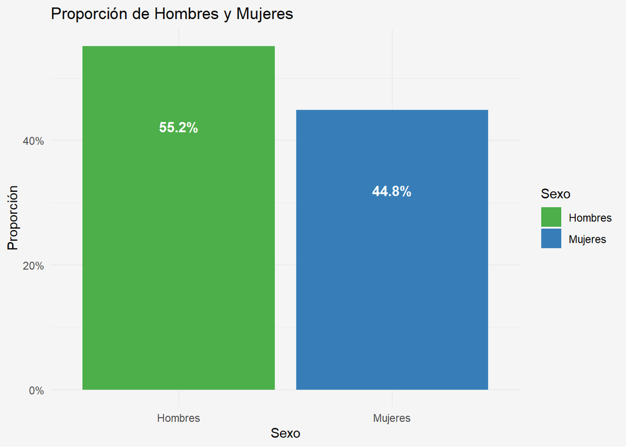

```r
sexo_counts <- esi_2022_ocupados %>%
  count(sexo_categorias) %>%
  mutate(prop = n / sum(n))

labels <- labs(title = "Proporción de hombres y mujeres ESI 2022",
       caption = "Elaboración propia en base a INE, Encuesta Suplementaria de Ingresos, 2022.",
       fill = "Sexo")

diseño_pie <- theme(
  legend.position = "none",
  plot.background = element_rect(fill = "#F5F5F5", color = NA),  # Fondo del plot
  panel.background = element_rect(fill = "#F5F5F5", color = NA), # Fondo del panel
  panel.border = element_blank(),  # Eliminar el borde del panel
  panel.grid.major = element_blank(),  # Eliminar la cuadrícula mayor
  panel.grid.minor = element_blank(),
  plot.title = element_text(color = "#015D3F", size = 15, hjust = 0.5, face = "bold"),
  legend.title = element_text(color = "#015D3F", face = "bold"),
  legend.text = element_text(color = "#015D3F", face = "bold", size = 6),
  plot.caption = element_text(hjust = 0, color = "#015D3F", face = "italic"),
  legend.background = element_rect(fill = "#F5F5F5", color = NA)  # Fondo de la leyenda
)


ggplot(sexo_counts, aes(x = sexo_categorias, y = prop, fill = sexo_categorias)) +
  geom_bar(stat = "identity") +
   geom_text(aes(label = percent(prop, accuracy = 0.1)),
            position = position_dodge(width = 0.7),
            vjust = 8,  # Ajuste vertical para las etiquetas
            size = 4,
            fontface = "bold",
            color = "white") +
  scale_fill_manual(values = palette)+
  scale_y_continuous(labels = scales::percent_format()) +
  labs(title = "Proporción de Hombres y Mujeres",
       x = "Sexo",
       y = "Proporción",
      fill = "Sexo") +
  theme_minimal() +
theme(
  plot.background = element_rect(fill = "#F5F5F5", color = NA)
)
```

### Tramos de Ingresos Principales según Sueldos Mínimos(2022)

```r
esi_2022_ocupados <- esi_2022_ocupados %>%
  mutate(
    ingreso_tramos = case_when(
      ing_t_p <= 350000 ~ "1SM o menos",
      ing_t_p > 350000 & ing_t_p <= 700000 ~ "Hasta 2SM",
      ing_t_p > 700000 & ing_t_p <= 1050000~ "Hasta 3SM",
      ing_t_p > 1050000 & ing_t_p <= 2100000~ "Hasta 6SM",
      ing_t_p > 2100000 ~ "Más de 8SM (2.1millones+)"
    )
  ) %>%
  filter(!is.na(ingreso_tramos))

moda_tramos_ingresos <- names(sort(table(esi_2022_ocupados$ingreso_tramos), decreasing = TRUE))[1]

kable(moda_tramos_ingresos, caption = "Moda Ingreso según Sueldos Mínimos(SM)")
```

Moda Ingreso según Sueldos Mínimos(SM)

| x |
| --- |
| Hasta 2SM |

```r
orden_ingreso_tramos <- c("1SM o menos","Hasta 2SM",
"Hasta 3SM",
"Hasta 6SM",
"Más de 8SM (2.1millones+)")


esi_2022_ocupados$ingreso_tramos <- factor(esi_2022_ocupados$ingreso_tramos, levels = orden_ingreso_tramos)

tc_tramos_ingresos <- table(esi_2022_ocupados$sexo_categorias, esi_2022_ocupados$ingreso_tramos)


tc_tramos_ingresos_relativa <- prop.table(tc_tramos_ingresos)



tc_tramos_ingresos_relativa%>%
  as.data.frame() %>%
  mutate(Freq = scales::percent(Freq, accuracy = 0.1)) %>%
  kable("html", col.names = c("Sexo", "Ingreso en SM(Sueldos Minimos)", "Proporción"), align = "c") %>%
  kable_styling(full_width = FALSE)
```

| Sexo | Ingreso en SM(Sueldos Minimos) | Proporción |
| --- | --- | --- |
| Hombres | 1SM o menos | 12.1% |
| Mujeres | 1SM o menos | 16.2% |
| Hombres | Hasta 2SM | 26.1% |
| Mujeres | Hasta 2SM | 18.7% |
| Hombres | Hasta 3SM | 8.6% |
| Mujeres | Hasta 3SM | 5.3% |
| Hombres | Hasta 6SM | 6.0% |
| Mujeres | Hasta 6SM | 3.7% |
| Hombres | Más de 8SM (2.1millones+) | 2.4% |
| Mujeres | Más de 8SM (2.1millones+) | 0.9% |

```r
esi_2022_ocupados <-  esi_2022_ocupados %>% filter(ing_t_p <= 3500000)

esi_2022_ingresos_tramos_prop <- esi_2022_ocupados %>%
  group_by(ingreso_tramos, sexo_categorias) %>%
  summarise(count = n()) %>%
  mutate(proporcion = count / sum(count)) %>%
  ungroup()
```

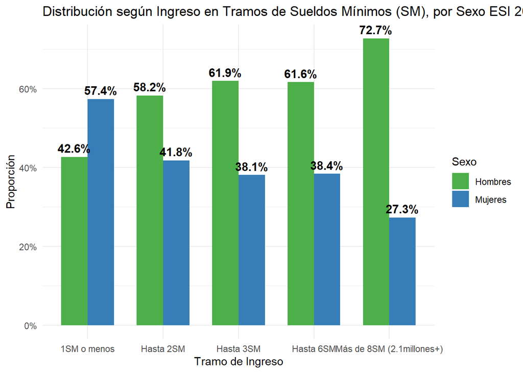

```r
ggplot(esi_2022_ingresos_tramos_prop, aes(x = ingreso_tramos, y = proporcion, fill = sexo_categorias)) +
  geom_bar(stat = "identity", position = "dodge", width = 0.7) +  # Usar position = "dodge" para dividir las barras
  geom_text(aes(label = percent(proporcion, accuracy = 0.1)),
            position = position_dodge(width = 0.7),
            vjust = -0.5,  # Ajuste vertical para las etiquetas
            size = 4,
            fontface = "bold",
            color = "black") +  # Cambiar el color de las etiquetas a negro
  labs(title = "Distribución según Ingreso en Tramos de Sueldos Mínimos (SM), por Sexo ESI 2022",
       x = "Tramo de Ingreso",
       y = "Proporción",
       fill = "Sexo") +
  scale_fill_manual(values = palette) +  # Colores personalizados
  scale_y_continuous(labels = percent_format(accuracy = 1)) +  # Formato de etiquetas en Y como porcentaje
  theme_minimal()
```

### Nivel Educativo

```r
esi_2022_ocupados <- esi_2022_ocupados %>% mutate(cine_categorias = case_when(
  cine %in% c(3,4) ~ "Primaria",
  cine %in% c(5) ~ "Secundaria",
  cine %in% c(6) ~ "Técnica",
  cine %in% c(7) ~ "Universitaria",
  cine %in% c(8,9) ~ "Postgrados",
  cine %in% c(999, 1) ~ NA
))

esi_2022_ocupados <- esi_2022_ocupados %>%
  filter(!is.na(cine_categorias))

moda_cine <- names(sort(table(esi_2022_ocupados$cine_categorias), decreasing = TRUE))[1]

kable(moda_cine, caption = "Estadísticos Descriptivos de Nivel Educativo, ESI 2022")
```

Estadísticos Descriptivos de Nivel Educativo, ESI 2022

| x |
| --- |
| Secundaria |

```r
orden_cine <- c("Primaria", "Secundaria", "Técnica", "Universitaria", "Postgrados")

esi_2022_ocupados$cine_categorias <- factor(esi_2022_ocupados$cine_categorias, levels = orden_cine)

tabla_contingencia_cine <- table(esi_2022_ocupados$cine_categorias, esi_2022_ocupados$sexo_categorias)

tabla_contingencia_cine_relativa <- prop.table(tabla_contingencia_cine)

tabla_contingencia_cine_relativa%>%
  as.data.frame() %>%
  mutate(Freq = scales::percent(Freq, accuracy = 0.1)) %>%
  kable("html", col.names = c("Nivel Educativo", "Sexo", "Proporción"), align = "c") %>%
  kable_styling(full_width = FALSE)
```

| Nivel Educativo | Sexo | Proporción |
| --- | --- | --- |
| Primaria | Hombres | 11.4% |
| Secundaria | Hombres | 25.6% |
| Técnica | Hombres | 6.0% |
| Universitaria | Hombres | 10.8% |
| Postgrados | Hombres | 1.2% |
| Primaria | Mujeres | 6.3% |
| Secundaria | Mujeres | 19.4% |
| Técnica | Mujeres | 7.2% |
| Universitaria | Mujeres | 11.0% |
| Postgrados | Mujeres | 1.2% |

```r
esi_2022_cine_prop <- esi_2022_ocupados %>%
  group_by(cine_categorias, sexo_categorias) %>%
  summarise(count = n())  %>%
  mutate(prop = count / sum(count)) %>%
  ungroup()
```

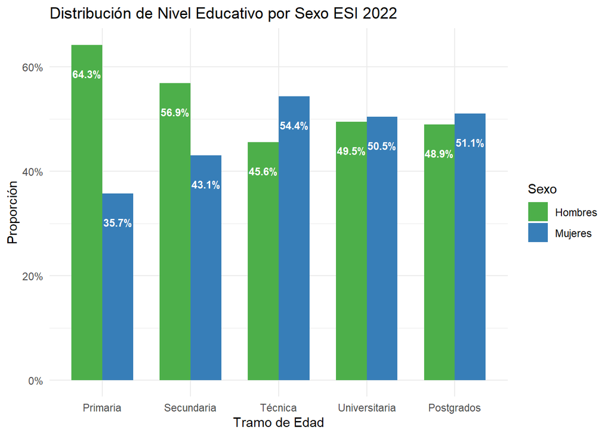

```r
ggplot(esi_2022_cine_prop, aes(x = cine_categorias, y = prop, fill = sexo_categorias)) +
  geom_bar(stat = "identity", position = "dodge", width = 0.7) +
  geom_text(aes(label = scales::percent(prop, accuracy = 0.1)),
            position = position_dodge(width = 0.7),
            vjust = 4,
            size = 3,
            fontface = "bold",
            color = "white") +
  labs(title = "Distribución de Nivel Educativo por Sexo ESI 2022",
       x = "Tramo de Edad",
       y = "Proporción",
       fill = "Sexo") +
  scale_fill_manual(values = palette) +
  scale_y_continuous(labels = scales::percent_format(accuracy = 1)) +
  theme_minimal()
```

### Ingresos Principales

```r
esi_2022_ingresos_filtrados <-  esi_2022_ocupados %>% filter(ing_t_p <= 3500000)

#Datos con ing_t_p <= $3.500.000
estadisticas_ingresos <- esi_2022_ingresos_filtrados  %>%
  summarise(
    Promedio = round(mean(ing_t_p, trim = 0.05, na.rm = TRUE)),
    Mediana = round(median(ing_t_p, na.rm = TRUE)),
    Minimo = min(ing_t_p, na.rm = TRUE),
    Maximo = max(ing_t_p, na.rm = TRUE),
    Asimetria = round(skew(ing_t_p, na.rm = TRUE), digits = 2),
    Curtosis = round(kurtosi(ing_t_p, na.rm = TRUE), digits = 2),
    Desv.Estandar = round(sd(ing_t_p, na.rm = TRUE))
  )


estadisticas_ingresos_formateadas <- estadisticas_ingresos %>%
  mutate(
    Promedio = format(Promedio, scientific = FALSE),
    Mediana = format(Mediana, scientific = FALSE),
    Minimo = format(Minimo, scientific = FALSE),
    Maximo = format(Maximo, scientific = FALSE),
    Asimetria = format(Asimetria, scientific = FALSE),
    Curtosis = format(Curtosis, scientific = FALSE),
    Desv.Estandar = format(Desv.Estandar, scientific = FALSE)
  )

kable(estadisticas_ingresos_formateadas, caption = "Estadísticos Descriptivos de Ingresos Principales, ESI 2022")
```

Estadísticos Descriptivos de Ingresos Principales, ESI 2022

| Promedio | Mediana | Minimo | Maximo | Asimetria | Curtosis | Desv.Estandar |
| --- | --- | --- | --- | --- | --- | --- |
| 543438 | 457369 | 0 | 3500000 | 2.22 | 6.42 | 508441 |

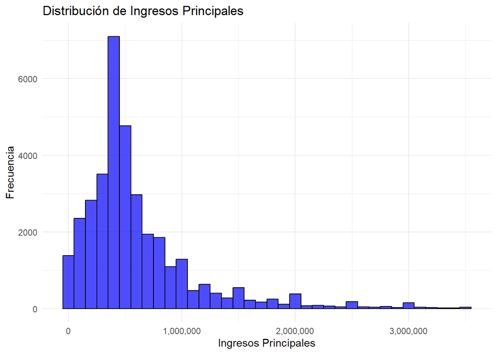

```r
ggplot(esi_2022_ocupados, aes(x = ing_t_p)) +
  geom_histogram(binwidth = 100000, fill = "blue", color = "black", alpha = 0.7) +
  labs(title = "Distribución de Ingresos Principales",
       x = "Ingresos Principales",
       y = "Frecuencia") +
  scale_x_continuous(labels = scales::comma_format()) +
  theme_minimal()
```

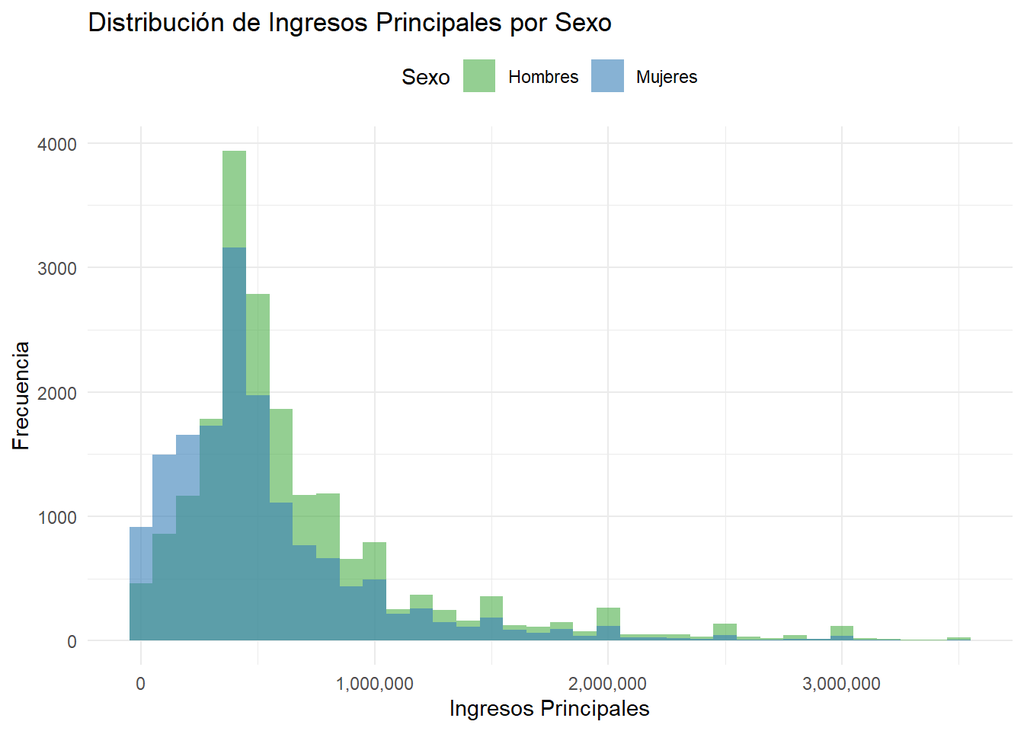

```r
ggplot(esi_2022_ocupados, aes(x = ing_t_p, fill = sexo_categorias)) +
  geom_histogram(binwidth = 100000, position = "identity", alpha = 0.6) +
  labs(title = "Distribución de Ingresos Principales por Sexo",
       x = "Ingresos Principales",
       y = "Frecuencia",
       fill = "Sexo") +
  scale_x_continuous(labels = scales::comma_format()) +  # Formato de etiquetas con separador de miles
  scale_fill_manual(values = palette)+
  theme_minimal() +
  theme(legend.position = "top")
```

### Edad

```r
#Nota: esi 2022 esta filtrada a máximo 3.5 millones de ingresos

estadisticos_edad<- esi_2022_ocupados %>%
  summarise(
    Promedio = round(mean(edad, trim = 0.05, na.rm = TRUE)),
    Mediana = round(median(edad, na.rm = TRUE)),
    Minimo = min(edad, na.rm = TRUE),
    Maximo = max(edad, na.rm = TRUE),
    Asimetria = round(skew(edad ,na.rm = TRUE), digits = 2),
    Curtosis = round(kurtosi(edad, na.rm = TRUE), digits = 2),
    Desv.Estandar = round(sd(edad, na.rm = TRUE))
  )

kable(estadisticos_edad, caption = "Estadísticos Descriptivos de la Edad")
```

Estadísticos Descriptivos de la Edad

| Promedio | Mediana | Minimo | Maximo | Asimetria | Curtosis | Desv.Estandar |
| --- | --- | --- | --- | --- | --- | --- |
| 44 | 44 | 15 | 91 | 0.17 | -0.81 | 14 |

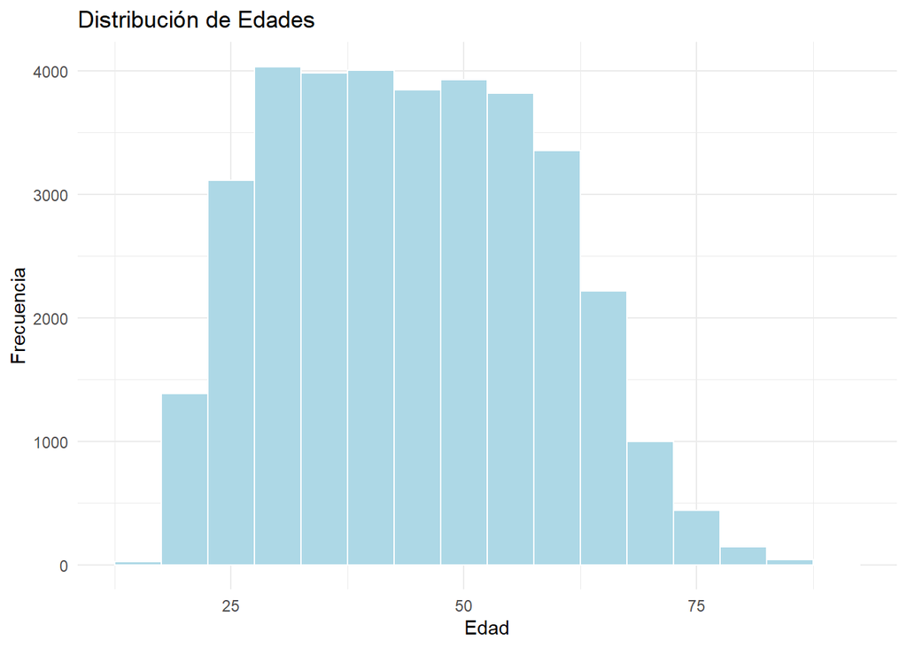

```r
ggplot(esi_2022_ocupados, aes(x = edad)) +
  geom_histogram(binwidth = 5, fill = "lightblue", color = "white", aes(y = after_stat(count))) +
  labs(title = "Distribución de Edades", x = "Edad", y = "Frecuencia") +
  theme_minimal()
```

### Tramos de Edad

```r
esi_2022_ocupados <- esi_2022_ocupados %>%
  mutate(grupos_edad = case_when(
    tramo_edad %in% c(1:2) ~ "15 a 19 años",
    tramo_edad %in% c(3:4) ~ "25 a 34 años",
    tramo_edad %in% c(5:6) ~ "35 a 44 años",
    tramo_edad %in% c(7:8) ~ "45 a 54 años",
    tramo_edad %in% c(9:10) ~ "55 a 64 años",
    tramo_edad %in% c(11:12) ~ "65 años o más"
  )) %>%  filter(!is.na(grupos_edad))


moda_grupo_edad <- names(sort(table(esi_2022_ocupados$grupos_edad), decreasing = TRUE))[1]

kable(moda_grupo_edad, caption = "Moda Grupos de Edades:")
```

Moda Grupos de Edades:

| x |
| --- |
| 35 a 44 años |

```r
orden_grupos_edad <- c("15 a 19 años", "25 a 34 años", "35 a 44 años", "45 a 54 años", "55 a 64 años", "65 años o más")

esi_2022_ocupados$grupos_edad<- factor(esi_2022_ocupados$grupos_edad, levels = orden_grupos_edad)

tc_tramos_edad <- table(esi_2022_ocupados$sexo_categorias, esi_2022_ocupados$grupos_edad)

tc_tramos_edad_relativa <- prop.table(tc_tramos_edad, margin = 2)

tc_tramos_edad_relativa%>%
  as.data.frame() %>%
  mutate(Freq = scales::percent(Freq, accuracy = 0.1)) %>%
  kable("html", col.names = c("Sexo", "Tramos de Edad", "Proporción"), align = "c") %>%
  kable_styling(full_width = FALSE)
```

| Sexo | Tramos de Edad | Proporción |
| --- | --- | --- |
| Hombres | 15 a 19 años | 58.0% |
| Mujeres | 15 a 19 años | 42.0% |
| Hombres | 25 a 34 años | 52.3% |
| Mujeres | 25 a 34 años | 47.7% |
| Hombres | 35 a 44 años | 51.4% |
| Mujeres | 35 a 44 años | 48.6% |
| Hombres | 45 a 54 años | 52.6% |
| Mujeres | 45 a 54 años | 47.4% |
| Hombres | 55 a 64 años | 58.7% |
| Mujeres | 55 a 64 años | 41.3% |
| Hombres | 65 años o más | 66.8% |
| Mujeres | 65 años o más | 33.2% |

```r
  esi_2022_tramos_prop <- esi_2022_ocupados %>%
  group_by(grupos_edad, sexo_categorias) %>%
  summarise(count = n()) %>%
  mutate(prop = count / sum(count)) %>%
  ungroup()
```

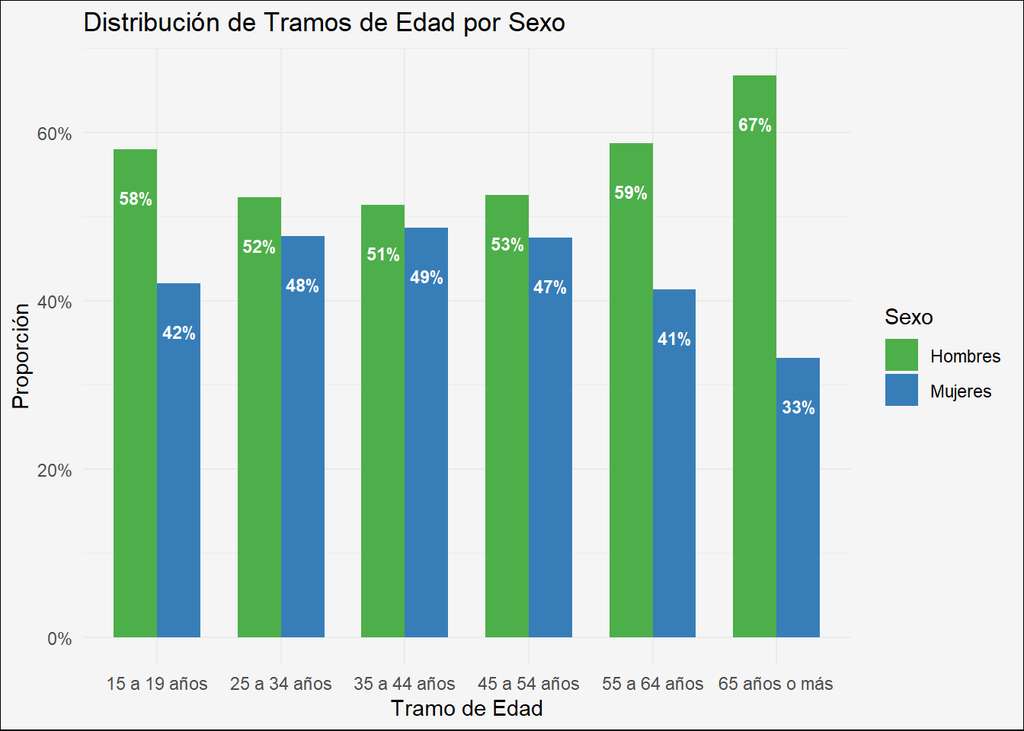

```r
# Graficar barras apiladas
ggplot(esi_2022_tramos_prop, aes(x = grupos_edad, y = prop, fill = sexo_categorias)) +
  geom_bar(stat = "identity", position = "dodge", width = 0.7) +
  geom_text(aes(label = scales::percent(prop, accuracy = 1)),
            position = position_dodge(width = 0.7),
            vjust = 4,
            size = 3,
            fontface = "bold",
            color = "white") +
  labs(title = "Distribución de Tramos de Edad por Sexo",
       x = "Tramo de Edad",
       y = "Proporción",
       fill = "Sexo") +
  scale_fill_manual(values = palette) +
  scale_y_continuous(labels = scales::percent_format(accuracy = 1)) +
  theme_minimal()+
  theme(
  plot.background = element_rect(fill = "#F5F5F5")
)
```

### Categorías de Ocupación

```r
esi_2022_ocupados <- esi_2022_ocupados %>%
  mutate(co_categorias = case_when(
    categoria_ocupacion == 1 ~ "Empleadores",
    categoria_ocupacion == 2 ~ "Trabajadores por Cuenta Propia",
    categoria_ocupacion %in% c(3, 4) ~ "Asalariados",
    categoria_ocupacion %in% c(5, 6) ~ "Personal de Servicio Doméstico",
    categoria_ocupacion == 7 ~ NA
  )) %>%  filter(!is.na(co_categorias))



moda_categorias_ocupacion <- names(sort(table(esi_2022_ocupados$co_categorias), decreasing = TRUE))[1]

kable(moda_categorias_ocupacion, caption = "Categorías de Ocupación")
```

Categorías de Ocupación

| x |
| --- |
| Asalariados |

```r
orden_categorias_ocupacion <- c("Empleadores", "Trabajadores por Cuenta Propia", "Asalariados", "Personal de Servicio Doméstico")

esi_2022_ocupados$co_categorias <- factor(esi_2022_ocupados$co_categorias, levels = orden_categorias_ocupacion)


tc_categorias_ocupacion <- table(esi_2022_ocupados$co_categorias, esi_2022_ocupados$sexo_categorias)

tc_categorias_ocupacion_relativas <- prop.table(tc_categorias_ocupacion)


tc_categorias_ocupacion_relativas%>%
  as.data.frame() %>%
  mutate(Freq = scales::percent(Freq, accuracy = 0.1)) %>%
  kable("html", col.names = c("Categoría de Ocupación", "Sexo", "Proporción"), align = "c") %>%
  kable_styling(full_width = FALSE)
```

| Categoría de Ocupación | Sexo | Proporción |
| --- | --- | --- |
| Empleadores | Hombres | 2.3% |
| Trabajadores por Cuenta Propia | Hombres | 12.9% |
| Asalariados | Hombres | 39.8% |
| Personal de Servicio Doméstico | Hombres | 0.1% |
| Empleadores | Mujeres | 0.9% |
| Trabajadores por Cuenta Propia | Mujeres | 10.1% |
| Asalariados | Mujeres | 30.9% |
| Personal de Servicio Doméstico | Mujeres | 3.0% |

```r
esi_2022_categorias_prop <- esi_2022_ocupados %>%
  group_by(co_categorias, sexo_categorias) %>%
  summarise(count = n()) %>%
  mutate(prop = count / sum(count)) %>%
  ungroup()
```

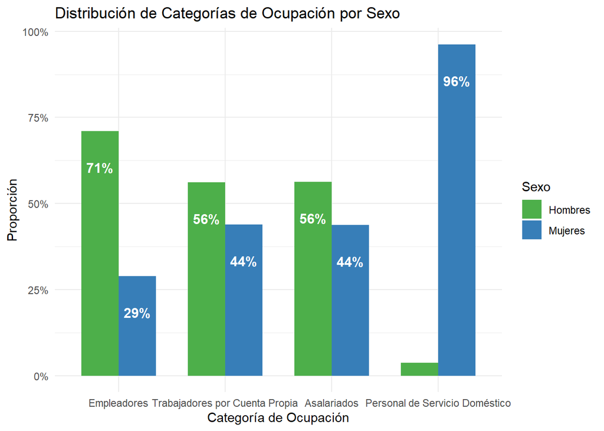

```r
ggplot(esi_2022_categorias_prop, aes(x = co_categorias, y = prop, fill = sexo_categorias)) +
  geom_bar(stat = "identity", position = "dodge", width = 0.7) +
  geom_text(aes(label = scales::percent(prop, accuracy = 1)),
            position = position_dodge(width = 0.7),
            vjust = 4,
            size = 4,
            fontface = "bold",
            color = "white") +
  labs(title = "Distribución de Categorías de Ocupación por Sexo",
       x = "Categoría de Ocupación",
       y = "Proporción",
       fill = "Sexo") +
  scale_fill_manual(values = palette) +
  scale_y_continuous(labels = scales::percent_format(accuracy = 1)) +
  theme_minimal()
```

### Macrozona

```r
esi_2022_ocupados <- esi_2022_ocupados %>%
  mutate(macrozona_categorias = case_when(
  region %in% c(1, 15, 2) ~ "Norte Grande",
  region %in% c(3, 4)  ~ "Norte Chico",
  region %in% c(5, 6, 7) ~ "Centro",
  region %in% c(13) ~ "Metropolitana",
  region %in% c(16, 8) ~ "Centro Sur",
  region %in% c(9, 10, 14) ~ "Sur",
  region %in% c(11, 12) ~ "Austral"
)) %>% filter(!is.na(macrozona_categorias))


moda_macrozona <- names(sort(table(esi_2022_ocupados$macrozona_categorias), decreasing = TRUE))[1]

kable(moda_macrozona, caption = "Estadísticos Descriptivos de la Edad")
```

| x |
| --- |
| Centro |

```r
orden_macrozona <- c("Norte Grande", "Norte Chico", "Centro", "Metropolitana", "Centro Sur", "Sur", "Austral")

esi_2022_ocupados$macrozona_categorias <- factor(esi_2022_ocupados$macrozona_categorias, levels = orden_macrozona)

tc_macrozona<- table(esi_2022_ocupados$macrozona_categorias, esi_2022_ocupados$sexo_categorias)

tc_macrozona_relativas <- prop.table(tc_macrozona)

tc_macrozona_relativas%>%
  as.data.frame() %>%
  mutate(Freq = scales::percent(Freq, accuracy = 0.1)) %>%
  kable("html", col.names = c("Macrozona", "Sexo", "Proporción"), align = "c") %>%
  kable_styling(full_width = FALSE)
```

| Macrozona | Sexo | Proporción |
| --- | --- | --- |
| Norte Grande | Hombres | 5.6% |
| Norte Chico | Hombres | 5.3% |
| Centro | Hombres | 13.8% |
| Metropolitana | Hombres | 10.7% |
| Centro Sur | Hombres | 8.2% |
| Sur | Hombres | 8.3% |
| Austral | Hombres | 3.2% |
| Norte Grande | Mujeres | 4.7% |
| Norte Chico | Mujeres | 4.2% |
| Centro | Mujeres | 10.9% |
| Metropolitana | Mujeres | 9.1% |
| Centro Sur | Mujeres | 6.6% |
| Sur | Mujeres | 6.5% |
| Austral | Mujeres | 2.9% |

```r
esi_2022_macrozona_prop <- esi_2022_ocupados %>%
  group_by(macrozona_categorias, sexo_categorias) %>%
  summarise(count = n()) %>%
  mutate(prop = count / sum(count)) %>%
  ungroup()
```

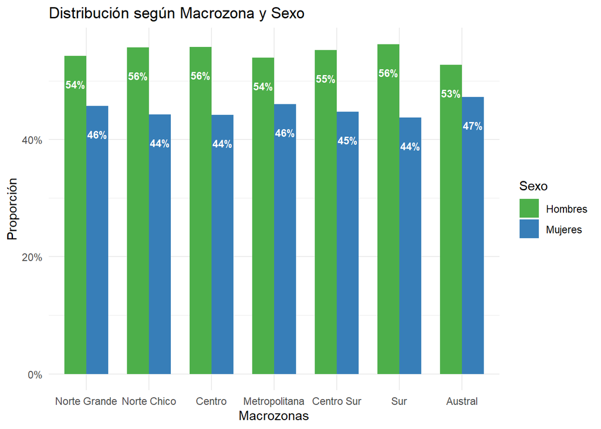

```r
ggplot(esi_2022_macrozona_prop, aes(x = macrozona_categorias, y = prop, fill = sexo_categorias)) +
  geom_bar(stat = "identity", position = "dodge", width =  0.7) +
  geom_text(aes(label = scales::percent(prop, accuracy = 1)),
            position = position_dodge(width = 0.7),
            vjust = 4,
            size = 3,
            fontface = "bold",
            color = "white") +
  labs(title = "Distribución según Macrozona y Sexo",
       x = "Macrozonas",
       y = "Proporción",
       fill = "Sexo") +
  scale_fill_manual(values = palette) +
  scale_y_continuous(labels = scales::percent_format(accuracy = 1)) +
  theme_minimal()
```

### Sector Económico

```r
esi_2022_ocupados <- esi_2022_ocupados %>%
  mutate(Sector_Economico = case_when(
    r_p_rev4cl_caenes %in% c(1, 2) ~ "Primaria",
    r_p_rev4cl_caenes %in% c(3, 4, 5 , 6) ~ "Secundaria",
    r_p_rev4cl_caenes %in% c(7:21) ~ "Terciaria"
  )) %>% filter(!is.na(Sector_Economico))

moda_sector_economico <- names(sort(table(esi_2022_ocupados$Sector_Economico), decreasing = TRUE))[1]

kable(moda_sector_economico, caption = "Moda Sector Económico, ESI 2022")
```

Moda Sector Económico, ESI 2022

| x |
| --- |
| Terciaria |

```r
orden_sector <- c("Primaria", "Secundaria", "Terciaria")

esi_2022_ocupados$Sector_Economico <- factor(esi_2022_ocupados$Sector_Economico, levels = orden_sector)


tc_sector_economico <- table(esi_2022_ocupados$Sector_Economico, esi_2022_ocupados$sexo_categorias)


tc_sector_economico_relativas <- prop.table(tc_sector_economico)


tc_sector_economico_relativas%>%
  as.data.frame() %>%
  mutate(Freq = scales::percent(Freq, accuracy = 0.1)) %>%
  kable("html", col.names = c("Sector Económico", "Sexo", "Proporción"), align = "c") %>%
  kable_styling(full_width = FALSE)
```

| Sector Económico | Sexo | Proporción |
| --- | --- | --- |
| Primaria | Hombres | 9.3% |
| Secundaria | Hombres | 15.1% |
| Terciaria | Hombres | 30.7% |
| Primaria | Mujeres | 2.4% |
| Secundaria | Mujeres | 4.4% |
| Terciaria | Mujeres | 38.1% |

```r
esi_2022_sector_prop <- esi_2022_ocupados %>%
  group_by(Sector_Economico, sexo_categorias) %>%
  summarise(count = n()) %>%
  mutate(prop = count / sum(count)) %>%
  ungroup()
```

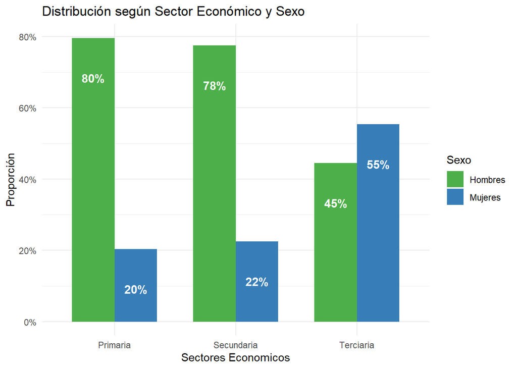

```r
ggplot(esi_2022_sector_prop, aes(x = Sector_Economico, y = prop, fill = sexo_categorias)) +
  geom_bar(stat = "identity", position = "dodge", width = 0.7) +
  geom_text(aes(label = scales::percent(prop, accuracy = 1)),
            position = position_dodge(width = 0.7),
            vjust = 5,
            size = 4,
            fontface = "bold",
            color = "white") +
  labs(title = "Distribución según Sector Económico y Sexo",
       x = "Sectores Economicos",
       y = "Proporción",
       fill = "Sexo") +
  scale_fill_manual(values = palette) +
  scale_y_continuous(labels = scales::percent_format(accuracy = 1)) +
  theme_minimal()
```

# Análisis Bivariado ESI 2022

Si bien la base de datos ya posee las variables a utilizar, es necesario realizar algunas recodificaciones para poder construir los gráficos

### Promedio por Macrozona

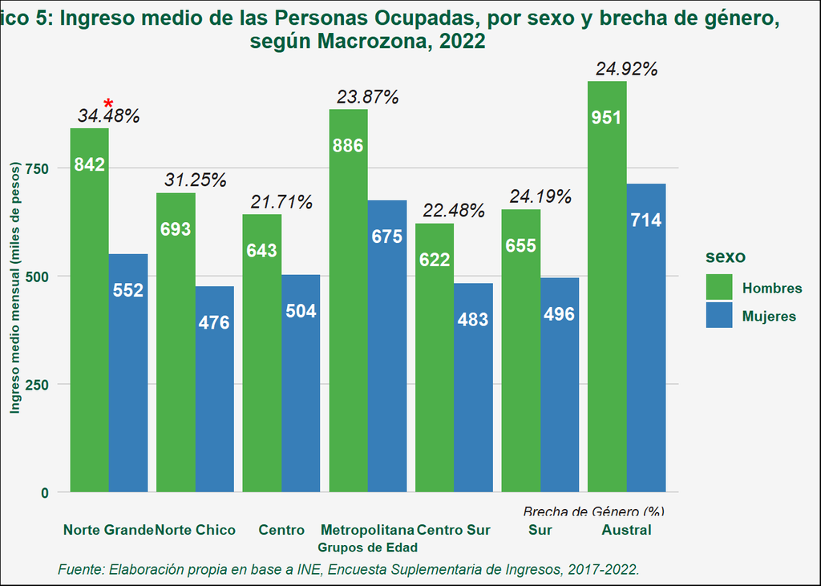

```r
esi_2022_ocupados_bivariado <- esi_2022_ocupados_bivariado %>%
  mutate(macrozona = case_when(
  region %in% c(1, 15, 2) ~ 1,
  region %in% c(3, 4)  ~ 2,
  region %in% c(5, 6, 7) ~ 3,
  region %in% c(13) ~ 4,
  region %in% c(16, 8) ~ 5,
  region %in% c(9, 10, 14) ~ 6,
  region %in% c(11, 12) ~ 7
))

ocupados_hombres_2022 <- esi_2022_ocupados_bivariado %>% filter(sexo == 1)
ocupados_mujeres_2022 <- esi_2022_ocupados_bivariado %>% filter(sexo == 2)

esi_2022_ocupados_bivariado <- esi_2022_ocupados_bivariado %>%  filter(!is.na(macrozona))

ingreso_mujeres_macrozona <- ocupados_mujeres_2022 %>%
  group_by(macrozona) %>%
  reframe(ingreso_medio_mujeres = mean(ing_t_p, na.rm = TRUE)) %>%
  ungroup()

View(ingreso_mujeres_macrozona)
  ingreso_hombres_macrozona <- ocupados_hombres_2022 %>%
  group_by(macrozona) %>%
  reframe(ingreso_medio_hombres = mean(ing_t_p, na.rm = TRUE)) %>%
  ungroup()

media_mujeres_macrozona <- ingreso_mujeres_macrozona$ingreso_medio_mujeres
media_hombres_macrozona <- ingreso_hombres_macrozona$ingreso_medio_hombres

ingreso_macrozona_hombres_miles2022 <- round(media_hombres_macrozona/ 1000)
ingreso_macrozona_mujeres_miles2022 <- round(media_mujeres_macrozona / 1000)

View(ingreso_macrozona_hombres_miles2022)

brecha_genero_macrozona <- round((1- media_mujeres_macrozona/ media_hombres_macrozona) * 100, digits = 2)




ingresos_por_macrozona <- data.frame(
  Macrozona = orden_macrozona,
  Promedio_Hombres =  ingreso_macrozona_hombres_miles2022,
  Promedio_Mujeres = ingreso_macrozona_mujeres_miles2022,
  Brecha_Salarial = brecha_genero_macrozona
)


# Definir orden personalizado de regiones

orden_macrozona <- c("Norte Grande", "Norte Chico", "Centro", "Metropolitana", "Centro Sur", "Sur", "Austral")




# Transformar los resultados en un dataframe largo para graficar
ingreso_macrozona_long <- ingresos_por_macrozona %>%
  pivot_longer(cols = c(Promedio_Hombres, Promedio_Mujeres),
               names_to = "sexo",
               values_to = "ingreso_medio") %>%
  mutate(sexo = recode(sexo,
                       "Promedio_Hombres" = "Hombres",
                       "Promedio_Mujeres" = "Mujeres"))

ingreso_macrozona_long$Macrozona <- factor(ingreso_macrozona_long$Macrozona, levels = orden_macrozona)

ingreso_macrozona_nortegrande <- ingreso_macrozona_long %>%
  filter(Macrozona == "Norte Grande")

ggplot(ingreso_macrozona_long, aes(x = Macrozona, y = ingreso_medio, fill = sexo)) +
    geom_bar(stat = "identity", position = "dodge") +
  geom_text(aes(label = ingreso_medio),
            position = position_dodge(width = 0.9),
            vjust = 3.0,
            hjust = 0.5,
            color = "white",
            fontface = "bold",
            size = 4) +
  geom_text(data = distinct(ingreso_macrozona_long, Macrozona, .keep_all = TRUE),
            aes(x = Macrozona,
                label = paste0(Brecha_Salarial, "%")),
            color = "#1F1B1C",
            size = 4,
            fontface = "italic",
            vjust = -0.5) +
  annotate("text", x = Inf, y = -5, label = "Brecha de Género (%)",
           hjust = 1.1, vjust = 2, size = 3, color = "#1F1B1C", fontface = "italic") +
 geom_text(data = distinct(ingreso_macrozona_nortegrande, Macrozona, .keep_all = TRUE),
            aes(label = "*"),
            color = "red", fontface = "bold", size = 6, vjust = -0.5) +
  labs(title = "Gráfico 5: Ingreso medio de las Personas Ocupadas, por sexo y brecha de género,
según Macrozona, 2022",
       x = "Grupos de Edad",
       y = "Ingreso medio mensual (miles de pesos)",
    caption = "Fuente: Elaboración propia en base a INE, Encuesta Suplementaria de Ingresos, 2017-2022.") +
  scale_fill_manual(values = palette) +
  scale_y_continuous(labels = scales::comma)+
  theme_minimal() +
  theme(plot.background = element_rect(fill = "#F5F5F5"),  # Cambiar el fondo a gris claro
        panel.grid.major = element_blank(),  # Eliminar la cuadrícula mayor
        panel.grid.minor = element_blank(),
        panel.grid.major.y = element_line(color = "#D3D3D3"),# Eliminar la cuadrícula menor
        plot.title = element_text(color = "#015D3F", size = 13, hjust = 0.5, face = "bold"),  # Color y tamaño del título
        axis.text = element_text(color = "#015D3F"),  # Color de texto de los ejes
        axis.text.x = element_text(face = "bold"),
        axis.text.y = element_text(face = "bold"),
        axis.title.x = element_text(color = "#015D3F", face = "bold", size = 8),  # Color de texto del eje x
        axis.title.y = element_text(color = "#015D3F", face = "bold", size = 8),
        legend.title = element_text(color = "#015D3F", face = "bold"),
        legend.text = element_text(color = "#015D3F", face = "bold"),
        plot.caption = element_text(hjust = 0, color = "#015D3F", face = "italic"))
```

###Tramos de Edad

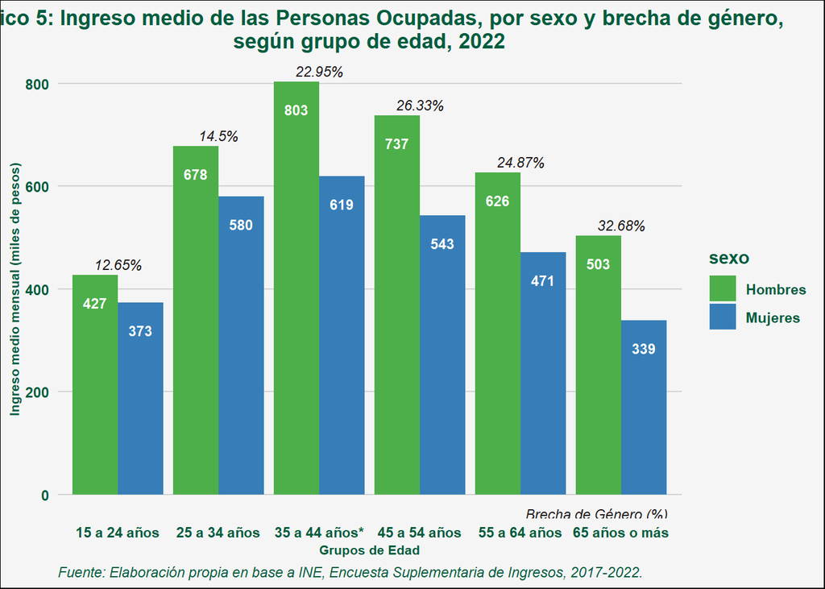

```r
esi_2022_ocupados <- esi_2022_ocupados %>%
  mutate(tramo_edad = case_when(
    tramo_edad %in% c(1:2) ~ 1,
    tramo_edad %in% c(3:4) ~ 2,
    tramo_edad %in% c(5:6) ~ 3,
    tramo_edad %in% c(7:8) ~ 4,
    tramo_edad %in% c(9:10) ~ 5,
    tramo_edad %in% c(11:12) ~ 6
  )) %>% filter(!is.na(tramo_edad))

ocupados_hombres_2022 <- esi_2022_ocupados %>% filter(sexo == 1)

ocupados_mujeres_2022 <- esi_2022_ocupados %>% filter(sexo == 2)

ingreso_hombres_edad <- ocupados_hombres_2022 %>%
  group_by(tramo_edad) %>%
  reframe(ingreso_medio_hombres = mean(ing_t_p, na.rm = TRUE)) %>%
  ungroup()



ingreso_mujeres_edad <- ocupados_mujeres_2022 %>%
  group_by(tramo_edad) %>%
  summarise(ingreso_medio_mujeres = mean(ing_t_p, na.rm = TRUE)) %>%
  ungroup()


media_mujeres_edad <- ingreso_mujeres_edad$ingreso_medio_mujeres
media_hombres_edad <- ingreso_hombres_edad$ingreso_medio_hombres

ingreso_edad_hombres_miles2022 <- round(media_hombres_edad/ 1000)
ingreso_edad_mujeres_miles2022 <- round(media_mujeres_edad / 1000)


brecha_genero_edad <- round((1- media_mujeres_edad/ media_hombres_edad) * 100, digits = 2)

orden_tramos <- c(
  "15 a 24 años", "25 a 34 años", "35 a 44 años*",
  "45 a 54 años", "55 a 64 años", "65 años o más"
)

ingresos_tramos_edad <- data.frame(
  Tramos_edad = orden_tramos,
  Promedio_Hombres =  ingreso_edad_hombres_miles2022,
  Promedio_Mujeres = ingreso_edad_mujeres_miles2022,
  Brecha_Salarial = brecha_genero_edad
)



# Transformar los resultados en un dataframe largo para graficar
ingreso_edad_long <- ingresos_tramos_edad %>%
  pivot_longer(cols = c(Promedio_Hombres, Promedio_Mujeres),
               names_to = "sexo",
               values_to = "ingreso_medio") %>%
  mutate(sexo = recode(sexo,
                       "Promedio_Hombres" = "Hombres",
                       "Promedio_Mujeres" = "Mujeres"))



# Convertir la columna 'region' en un factor con el orden deseado
ingreso_edad_long$Tramos_edad <- factor(ingreso_edad_long$Tramos_edad, levels = orden_tramos)

ingreso_35_44 <- ingreso_edad_long %>%
  filter(Tramos_edad == "35 a 44 años")


ggplot(ingreso_edad_long, aes(x = Tramos_edad, y = ingreso_medio, fill = sexo)) +
  geom_bar(stat = "identity", position = "dodge") +
  geom_text(aes(label = ingreso_medio),
            position = position_dodge(width = 0.9),
            vjust = 3.0,
            hjust = 0.5,
            color = "white",
            fontface = "bold",
            size = 3) +
  geom_text(data = distinct(ingreso_edad_long, Tramos_edad, .keep_all = TRUE),
            aes(x = Tramos_edad,
                label = paste0(Brecha_Salarial, "%")),
            color = "#1F1B1C",
            size = 3,
            fontface = "italic",
            vjust = -0.5) +
  annotate("text", x = Inf, y = -5, label = "Brecha de Género (%)",
           hjust = 1.1, vjust = 2, size = 3, color = "#1F1B1C", fontface = "italic") +
    geom_text(data = distinct(ingreso_35_44, Tramos_edad, .keep_all = TRUE),
            aes(label = "*"),
            color = "red", fontface = "bold", size = 5, vjust = -0.5) +
  labs(title = "Gráfico 5: Ingreso medio de las Personas Ocupadas, por sexo y brecha de género,
según grupo de edad, 2022",
       x = "Grupos de Edad",
       y = "Ingreso medio mensual (miles de pesos)",
    caption = "Fuente: Elaboración propia en base a INE, Encuesta Suplementaria de Ingresos, 2017-2022.") +
  scale_fill_manual(values = palette) +
  scale_y_continuous(labels = scales::comma)+
  theme_minimal() +
  theme(plot.background = element_rect(fill = "#F5F5F5"),  # Cambiar el fondo a gris claro
        panel.grid.major = element_blank(),  # Eliminar la cuadrícula mayor
        panel.grid.minor = element_blank(),
        panel.grid.major.y = element_line(color = "#D3D3D3"),# Eliminar la cuadrícula menor
        plot.title = element_text(color = "#015D3F", size = 13, hjust = 0.5, face = "bold"),  # Color y tamaño del título
        axis.text = element_text(color = "#015D3F"),  # Color de texto de los ejes
        axis.text.x = element_text(face = "bold"),
        axis.text.y = element_text(face = "bold"),
        axis.title.x = element_text(color = "#015D3F", face = "bold", size = 8),  # Color de texto del eje x
        axis.title.y = element_text(color = "#015D3F", face = "bold", size = 8),
        legend.title = element_text(color = "#015D3F", face = "bold"),
        legend.text = element_text(color = "#015D3F", face = "bold"),
        plot.caption = element_text(hjust = 0, color = "#015D3F", face = "italic"))
```

### Categoría Ocupación